# Informe Primer Semestre 2021

Humanidades

Claudio Rojas. Director Académico

2021-07-31

## 0.1 Presentación

El presente informe tiene como objetivo revisar el trabajo del sector, a través de información que sistematiza los resultados académicos del I semestre y recoge lo proyectado para el II semestre del presente año. Además, consideran las definiciones claves que tenemos como colegio pero también como institución de la Compañía de Jesús.

Los apartados del informe son:

- Definiciones Claves
- Informe de Notas
- Metas de Aprendizaje.
- Propuestas de Evaluación II Semestre.
- Sugerencias para la planificación de las unidades 2 y 3.

Cada una de las partes de informe incluye sugerencias que buscan orientar la reflexión y práctica del sector para poder realizar los ajustes que sean necesarios para el logro de los aprendzajes que sean definidos.

## 0.2 Definiciones Claves

Les recuerdo tener presente las definiciones claves tanto a nivel de red ignaciana como interna que deben siempre orientar nuestro trabajo académico.

### 0.2.1 Envío 3 Planificación Estratégica de los colegios Jesuitas

Asegurar que los 10 colegios y escuelas jesuitas desarrollen las prácticas y procesos necesarios para ofrecer la excelencia académica propia de una comprensión ignaciana de la educación de calidad.

### 0.2.2 Nuestra Definición de Calidad

Nosotros, como comunidad sanjavierina, entendemos por educación de calidad todo aprendizaje que nos lleva a descubrir y desarrollar nuestras capacidades de manera integral, formándonos como personas competentes, conscientes, comprometidas, compasivas y creativas, para así conocer y amar más y mejor a Jesucristo, sirviendo a nuestros hermanos en los diversos contextos sociales.

### 0.2.3 Nuestro Foco de Mejora

Fortalecer la propuesta curricular, con una didáctica renovada, bajo el Paradigma Pedagógico Ignaciano.

## 0.3 Informe de Notas

El informe de notas contiene la siguiente información:

- Tabla de Resumen de las notas por nivel.
- Notas de 1º básico a IVº medio.
- Distribución por Niveles de Logro

En el caso de los resultados, les sugiero analizar:

- Los promedios finales obtenidos por cada nivel
- Cantidad de estudiantes que están en cada nivel de logro.
- Las diferencias de resultados entre hombres y mujeres.

### 0.3.1 Tabla Resumen de Notas:

La tres tablas siguintes incluye la información de la asignatura por nivel en cuanto:

- Promedio de la asignatura.
- Nota Mínima.
- Mediana.
- Nota Máxima.

#### 0.3.1.1 Tabla 1: Historia

[output not shown]

#### 0.3.1.2 Tabla 2: Filosofía (Nivel Tercero Medio)

| Nivel | Promedio | Mediana | NotaMínima | NotaMáxima |
| --- | --- | --- | --- | --- |
| 11 | 6.2 | 6.2 | 3 | 7 |

#### 0.3.1.3 Tabla 3: Educación Ciudadana (Nivel Cuarto Medio)

| Nivel | Promedio | Mediana | NotaMínima | NotaMáxima |
| --- | --- | --- | --- | --- |
| 12 | 6.55 | 6.55 | 1 | 7 |

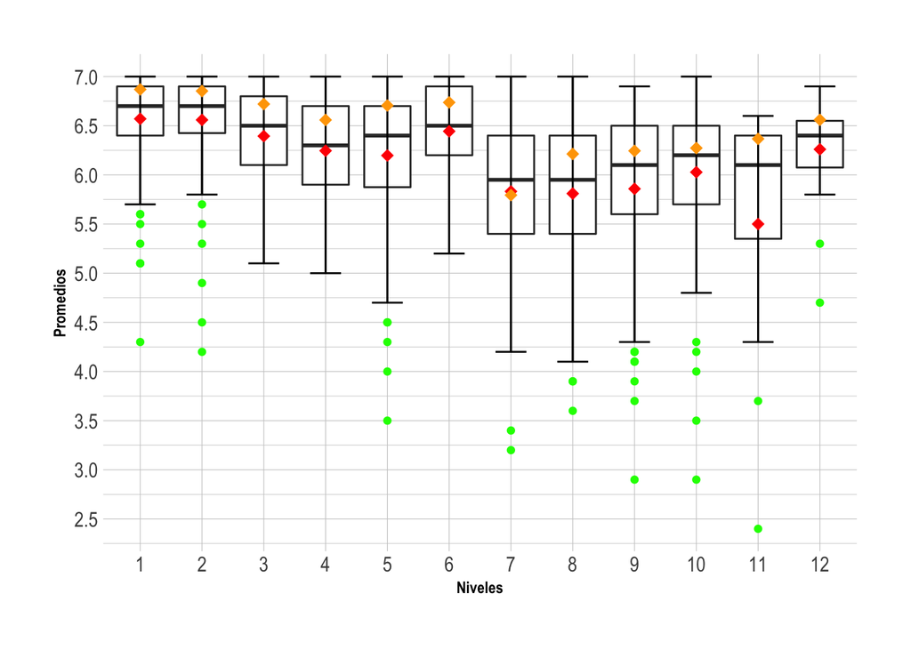

### 0.3.3 Distribución de Estudiantes por Niveles de Logro y diferenciado por Sexo.

En este caso, se muestran los resultados de Historia hasta IIº medio.. En el caso de IIIº se grafican los resultados de Filosofía y en IVº medio, los resultados de Educación Ciudadana.

#### 0.3.3.1 Primeros Básicos

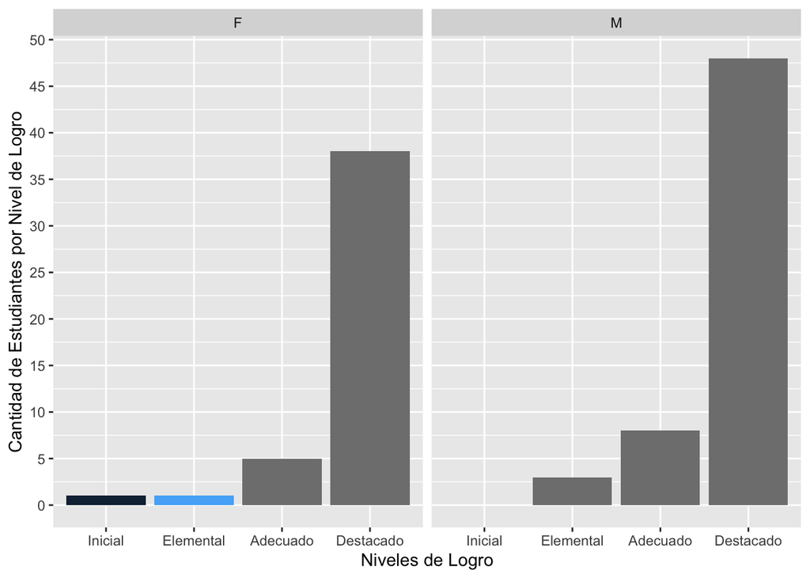

### Segundos Básicos

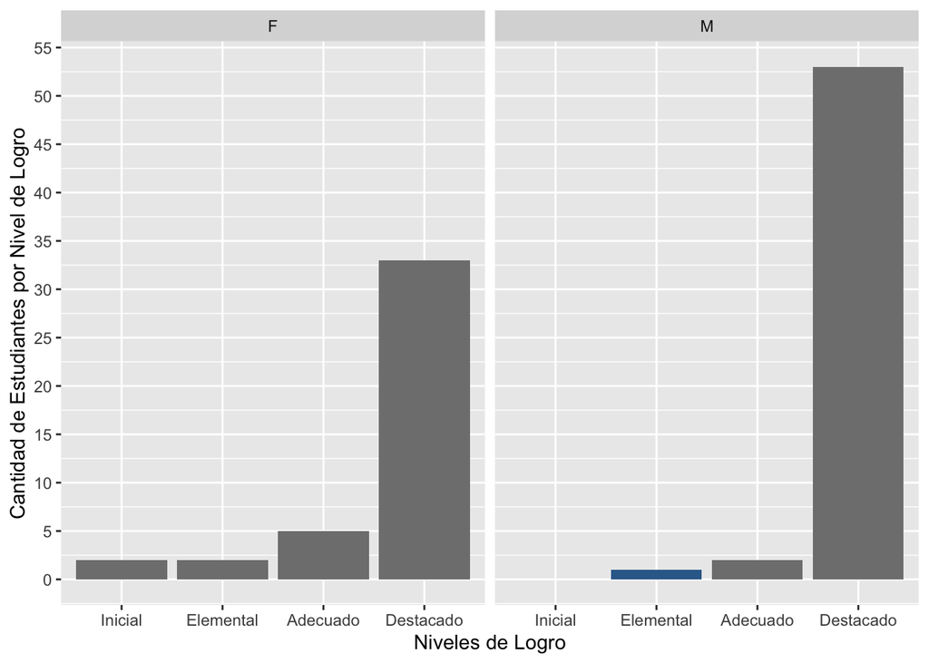

#### 0.3.3.2 Terceros Básicos

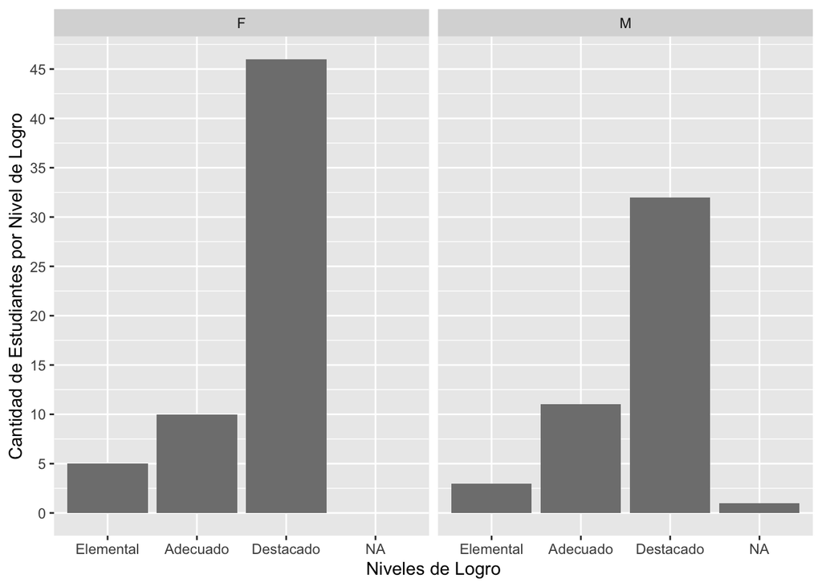

#### 0.3.3.3 Cuartos Básicos

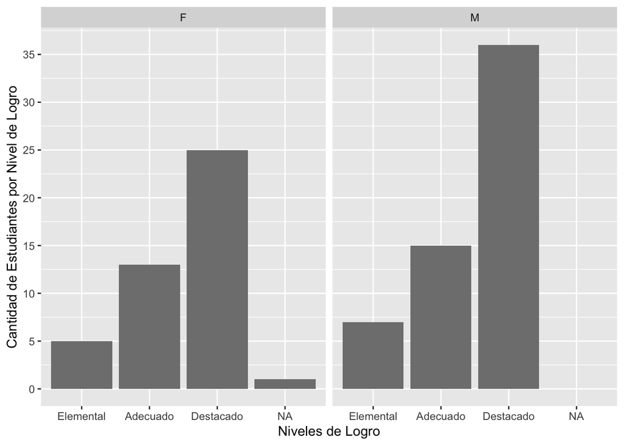

#### 0.3.3.4 Quintos Básicos

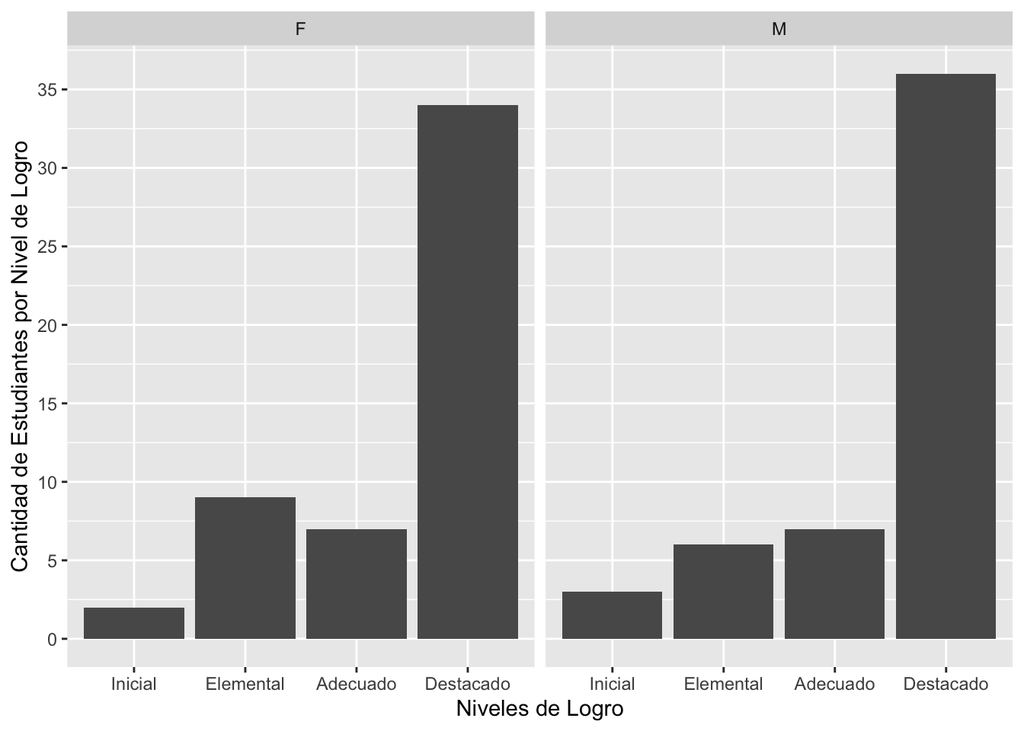

#### 0.3.3.5 Sextos Básicos

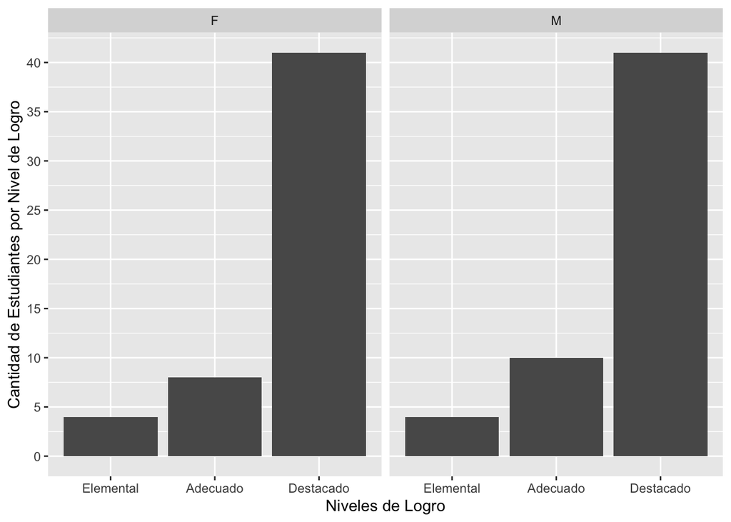

#### 0.3.3.6 Séptimos Básicos

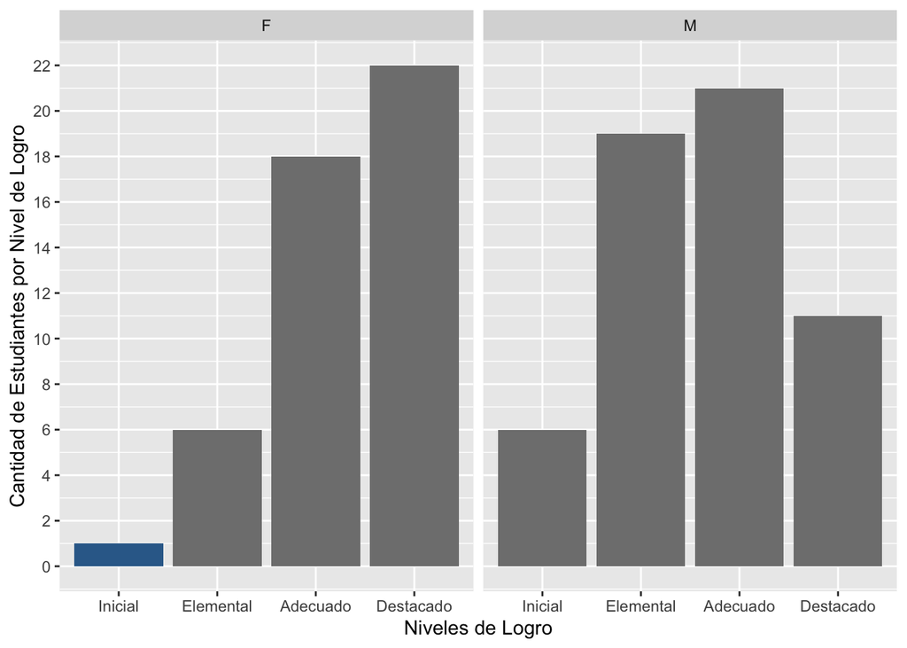

#### 0.3.3.7 Octavos Básicos

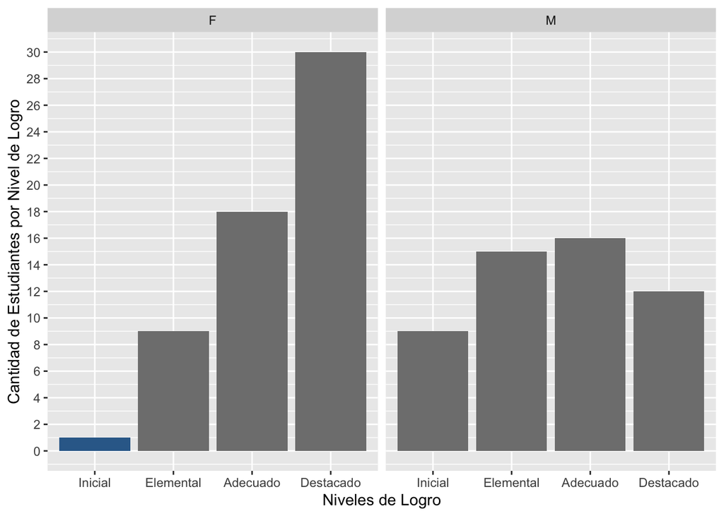

#### 0.3.3.8 Primeros Medios

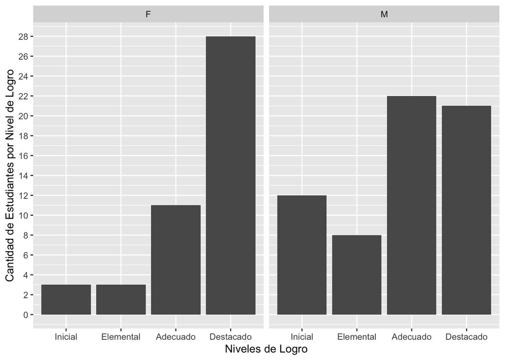

#### 0.3.3.9 Segundos Medios

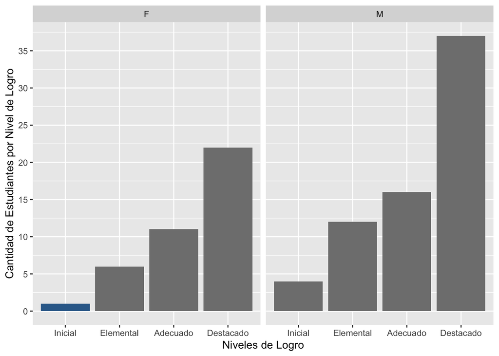

#### 0.3.3.10 Terceros Medios Filosofia

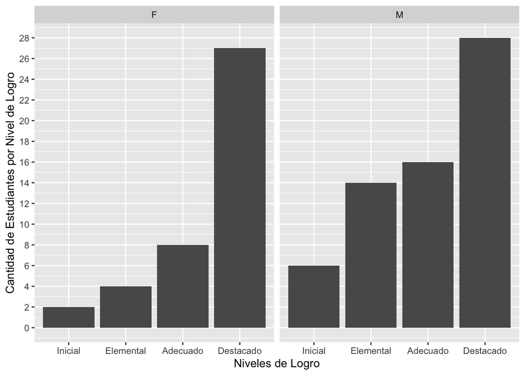

#### 0.3.3.11 Cuartos Medios Educación Ciudadana

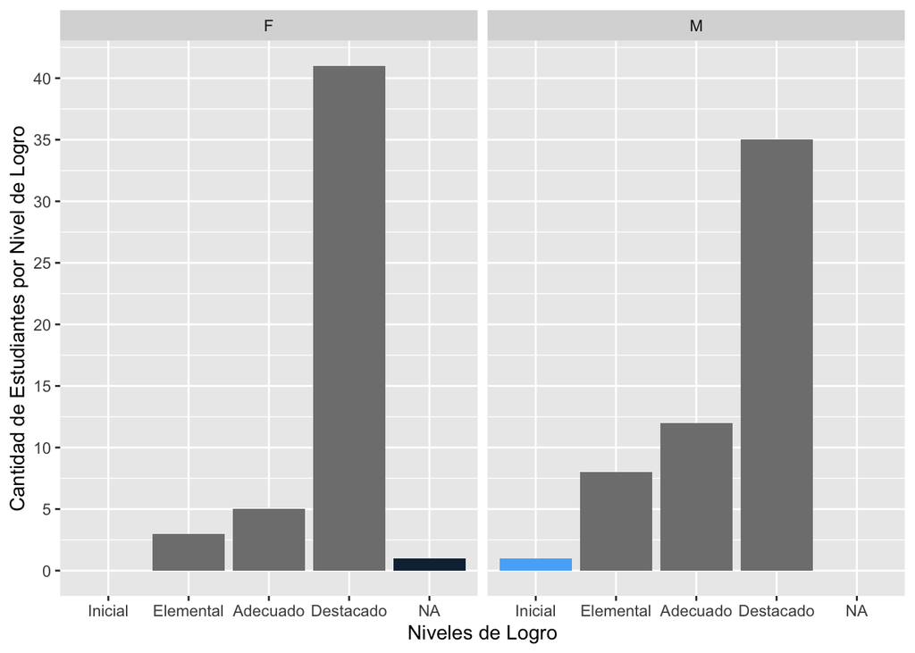

## 0.4 Metas de Aprendizajes

Se presentan las metas declaradas por el sector desde 1º básico a IIº medio. En el caso de IIIº medio, las metas que se incluyen corresponden a Educación Ciudadana y Filosofía (al 15 de julio). Ajustar las metas considerando los siguientes criterios:

- **¿Contienen errores gramaticales:** **Redacción, Faltas de Ortografía** **?**
- **¿Están escritas de manera clara y precisa?** Ejemplo *“Reflexionar sobre la diversidad cultural y geográfica del continente argumentando con fuentes dadas y mapas. (Cuarto básico)”* o *" Reconocer el valor del respeto a la diversidad, mediante la caracterización y representación del proceso de conquista de América y periodo Colonial."* **¿Qué se entiende por reflexionar o reconocer el valor del respeto? ¿Cómo se evaluarán?**
- **¿Se usan los verbos adecuados?** Ejemplo: **“Se espera que los estudiantes identifiquen y ubiquen (Primero Básico)”**. **Priorizar verbos que engloben más que una secuencia de éstos.**
- **¿Dan cuenta de aprendizajes relevantes que deben adquirir mis estudiantes? ¿Es coherente con el plan de estudios?**
- **¿La meta da cuenta de aprendizajes o de productos a lograr?** Ejemplo: *“Elaborar una cápsula digital informativa acerca de casos reales que ponen en riesgo la participación ciudadana y la democracia en el Chile actual” (Tercero medio).* **En este caso, más que una meta es la evaluación de la meta.**
- **Ajustar las metas que contengan verbos que son poco precisos a la hora de medir:** *Comprender, Reflexionar*. **Pero también, aquellas que contengan verbos que den cuenta de niveles básicos de aprendizaje:** *Identificar, Reconocer*. **Las metas de aprendizajes deben ser** *Medibles* **pero también** *Desafiantes*.

### 0.4.1 Metas de Aprendizajes Primer Ciclo

[output not shown]

### 0.4.2 Metas de Aprendizajes Segundo Ciclo

| Nivel | Segunda Unidad | Tercera Unidad |
| --- | --- | --- |
| Tercero básico | Explicar, cómo los seres humanos se han adaptado a las diferentes zonas climáticas de la tierra, utilizando herramientas geográficas y puntos de referencia a través de opiniones fundamentadas | Comparar los modos de vida de los griegos y romanos con nuestra sociedad, reconociendo las estrategias utilizadas en la antigüedad para resolver desafíos de la comunidad. |
| Cuarto básico | Reflexionar sobre la diversidad cultural y geográfica del continente argumentando con fuentes dadas y mapas. | Reflexionar sobre el legado de las civilizaciones americanas en nuestra sociedad por medio de la comparación de fuentes dadas. |
| Quinto básico | Evaluar los desafíos y oportunidades de las zonas naturales mediante las opiniones fundadas y el uso de mapas. | Reconocer el valor del respeto a la diversidad, mediante la caracterización y representación del proceso de conquista de América y periodo Colonial. |
| Sexto básico | Identificar las posibilidades y desafíos de las diferentes zonas del país y comunicarlas a través de una inforgrafía. | Caracterizar los principales hitos y procesos que le permitieron conformarse como una sociedad democrática, mediante la elaboración de un periódico de forma grupal. |

### 0.4.3 Metas de Aprendizajes Tercer y Cuarto Ciclo

[output not shown]

## 0.5 Plan de Evaluación II Semestre 2021

En la siguiente tabla se presentan los procedimientos e instrumentos declarados por el sector (1º básico en adelante) y la cantidad de veces que se repiten. Revisar lo declarado en el plan de evaluación considerando los siguientes criterios:

- ¿Hay claridad en el sector entre lo que es un procedimiento y su diferencia con el instrumento? **En el caso de dudas, revisar nuestro [Reglamento de Evaluación](https://www.colsanjavier.cl/files/documentos/REGLAMENTO%20INTERNO%20DE%20EVALUACIÓN%202021.%20%5Bv.%2030-04-2021%5D.pdf).**
- **¿Existe una diversidad de formas de evaluar o se limitan a la práctica recurrente de procedimientos e instrumentos utilizados en el sector?**.**Es necesario revisar si, en la implementación, hay diferencias metodológicas entre** *Exposición oral o Presentación oral* **o simplemente, estamos denominado de distinta manera una clásica disertación. Se debe consensuar que se entenderá en el sector por** *Investigación, Ensayo o Exposición oral* . **Eso puede permitir definir una línea de trabajo del equipo.**
- **¿Lo declarado, permite dar cuenta de manera adecuada de los OA y de las metas definidas en el sector?**

Por último, se agrega una nube de palabras que quiere reflejar el peso de los instrumentos/procedimientos declarados por el sector.En este caso, se incorporó lo declarado en Historia, Filosofía y Educación Ciudadana.

|  | word | freq |
| --- | --- | --- |
| prueba | prueba | 17 |
| pdt | pdt | 8 |
| test | test | 5 |
| investigación | investigación | 4 |
| líneat | líneat | 3 |
| ensayo | ensayo | 3 |
| exposición | exposición | 3 |
| representación | representación | 3 |
| trabajo | trabajo | 2 |
| investigacion | investigacion | 2 |
| comparación | comparación | 1 |
| interpretaciónfh | interpretaciónfh | 1 |
| presentaciónoral | presentaciónoral | 1 |
| afiche | afiche | 1 |
| esquemamapa | esquemamapa | 1 |
| infografia | infografia | 1 |
| infografía | infografía | 1 |
| tríptico | tríptico | 1 |
| avance | avance | 1 |
| construcción | construcción | 1 |

[interactive chart not shown]

En el caso del **Plan de Nivel**, les solicito que cómo sector concuerden y plasmen en la planificación:

- En qué sesiones se evaluará el o los OA que se hacen responsables.
- El o los instrumentos que usarán para concretar esta evaluación.

Es importante que ustedes como jefes de sector hagan sequimiento de este proceso, ya que es el medio con el cual concretamos la formación integral. Pero, además, los resultados obtenidos, es lo que informamos a los estudiantes y sus familias en los distintos objetivos de aprendizajes asociados a las tres dimensiones de nuestro Mapa de Formación Integral.